# Nadeem Bishtawi Assignment 9

### Library Import and Basic Data description

```python
!pip install contractions
```

```
     |████████████████████████████████| 106 kB 9.2 MB/s
     |████████████████████████████████| 284 kB 46.1 MB/s
```

```python
import re, string, unicodedata                                          #Used for Text PreProcessing
import numpy as np
import random
import pandas as pd
import matplotlib.pyplot as plt                                         # Used for plotting
import seaborn as sns                                                   # Used for plotting
from collections import Counter                                           # count the key-value pairs in an object

from wordcloud import WordCloud, STOPWORDS, ImageColorGenerator           # Used for plotting the wordcloud of a corpus
import nltk                                                               # Used for different task of NLP
nltk.download('stopwords')                              # Download Stopwords.
nltk.download('punkt')
nltk.download('wordnet')
from nltk.corpus import stopwords                                         # Used for removal of stop words
import warnings
warnings.filterwarnings("ignore")
from nltk.stem.porter import PorterStemmer

import contractions                                     # Import contractions library.
from bs4 import BeautifulSoup                           # Import BeautifulSoup.

from nltk.corpus import stopwords                       # Import stopwords.
from nltk.tokenize import word_tokenize, sent_tokenize  # Import Tokenizer.
from nltk.stem.wordnet import WordNetLemmatizer         # Import Lemmatizer.
from sklearn.feature_extraction.text import CountVectorizer
from sklearn.model_selection import train_test_split
from sklearn.feature_extraction.text import TfidfVectorizer
import wordcloud
from sklearn.ensemble import RandomForestClassifier
from sklearn.model_selection import cross_val_score
from sklearn.metrics import classification_report
from sklearn.metrics import accuracy_score
from sklearn.metrics import confusion_matrix
```

```python
from google.colab import drive
drive.mount('/content/drive')
```

```python
data = pd.read_csv('/content/drive/My Drive/AIML/Project 9/Tweets.csv')
df = data.copy()
```

```python
df.head()
```

|  | tweet_id | airline_sentiment | airline_sentiment_confidence | negativereason | negativereason_confidence | airline | airline_sentiment_gold | name | negativereason_gold | retweet_count | text | tweet_coord | tweet_created | tweet_location | user_timezone |
| --- | --- | --- | --- | --- | --- | --- | --- | --- | --- | --- | --- | --- | --- | --- | --- |
| 0 | 570306133677760513 | neutral | 1.0000 | NaN | NaN | Virgin America | NaN | cairdin | NaN | 0 | @VirginAmerica What @dhepburn said. | NaN | 2015-02-24 11:35:52 -0800 | NaN | Eastern Time (US & Canada) |
| 1 | 570301130888122368 | positive | 0.3486 | NaN | 0.0000 | Virgin America | NaN | jnardino | NaN | 0 | @VirginAmerica plus you've added commercials t... | NaN | 2015-02-24 11:15:59 -0800 | NaN | Pacific Time (US & Canada) |
| 2 | 570301083672813571 | neutral | 0.6837 | NaN | NaN | Virgin America | NaN | yvonnalynn | NaN | 0 | @VirginAmerica I didn't today... Must mean I n... | NaN | 2015-02-24 11:15:48 -0800 | Lets Play | Central Time (US & Canada) |
| 3 | 570301031407624196 | negative | 1.0000 | Bad Flight | 0.7033 | Virgin America | NaN | jnardino | NaN | 0 | @VirginAmerica it's really aggressive to blast... | NaN | 2015-02-24 11:15:36 -0800 | NaN | Pacific Time (US & Canada) |
| 4 | 570300817074462722 | negative | 1.0000 | Can't Tell | 1.0000 | Virgin America | NaN | jnardino | NaN | 0 | @VirginAmerica and it's a really big bad thing... | NaN | 2015-02-24 11:14:45 -0800 | NaN | Pacific Time (US & Canada) |

- Sentiment has 3 classes Positive, Neutral and Negative
- Most columns are either useless for prediciton or seem to be missing many values

```python
df.shape
```

```
(14640, 15)
```

```python
df.info()
```

```
<class 'pandas.core.frame.DataFrame'>
RangeIndex: 14640 entries, 0 to 14639
Data columns (total 15 columns):
 #   Column                        Non-Null Count  Dtype
---  ------                        --------------  -----
 0   tweet_id                      14640 non-null  int64
 1   airline_sentiment             14640 non-null  object
 2   airline_sentiment_confidence  14640 non-null  float64
 3   negativereason                9178 non-null   object
 4   negativereason_confidence     10522 non-null  float64
 5   airline                       14640 non-null  object
 6   airline_sentiment_gold        40 non-null     object
 7   name                          14640 non-null  object
 8   negativereason_gold           32 non-null     object
 9   retweet_count                 14640 non-null  int64
 10  text                          14640 non-null  object
 11  tweet_coord                   1019 non-null   object
 12  tweet_created                 14640 non-null  object
 13  tweet_location                9907 non-null   object
 14  user_timezone                 9820 non-null   object
dtypes: float64(2), int64(2), object(11)
memory usage: 1.7+ MB
```

### Missing Value analysis

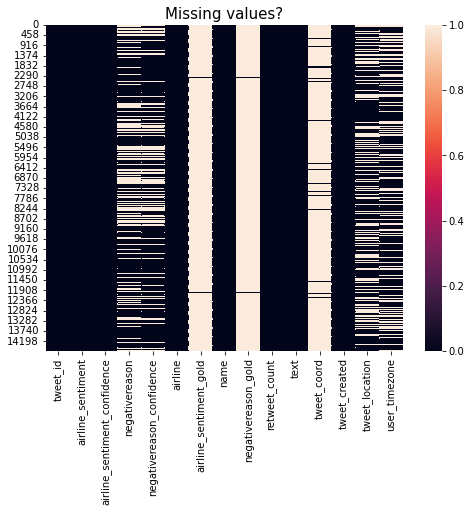

```python
plt.figure(figsize=(8,6))
sns.heatmap(df.isnull())                                  #Visualization of missing value using heatmap
plt.title("Missing values?", fontsize = 15)
plt.show()
```

```python
df.isna().sum()
```

```
tweet_id                            0
airline_sentiment                   0
airline_sentiment_confidence        0
negativereason                   5462
negativereason_confidence        4118
airline                             0
airline_sentiment_gold          14600
name                                0
negativereason_gold             14608
retweet_count                       0
text                                0
tweet_coord                     13621
tweet_created                       0
tweet_location                   4733
user_timezone                    4820
dtype: int64
```

```python
def missing_zero_values_table(df):
        zero_val = (df == 0.00).astype(int).sum(axis=0)                                            # Nu of zero in each column
        mis_val = df.isnull().sum()                                                                #Missing value in each column
        mis_val_percent = 100 * df.isnull().sum() / len(df)                                        #Missing value percent accross column
        mz_table = pd.concat([zero_val, mis_val, mis_val_percent], axis=1)                         #Concatenation of above aoutput
        mz_table = mz_table.rename(
        columns = {0 : 'Zero Values', 1 : 'Missing Values', 2 : '% of Total Values'})               #Renaming of each coumn
        mz_table['Total Zero Missing Values'] = mz_table['Zero Values'] + mz_table['Missing Values']  #column having total of zero value and missing values
        mz_table['% Total Zero Missing Values'] = 100 * mz_table['Total Zero Missing Values'] / len(df) # Column having percentage of totalof zero and missing value
        mz_table['Data Type'] = df.dtypes
        mz_table = mz_table[
            mz_table.iloc[:,1] != 0].sort_values(                                                     #Selecting and sorting those column which have at not a zero value in % of Total Values column
        '% of Total Values', ascending=False).round(1)
        print ("Your selected dataframe has " + str(df.shape[1]) + " columns and " + str(df.shape[0]) + " Rows.\n"
            "There are " + str(mz_table.shape[0]) +
              " columns that have missing values.")
#         mz_table.to_excel('D:/sampledata/missing_and_zero_values.xlsx', freeze_panes=(1,0), index = False)
        return mz_table

missing_zero_values_table(df)
```

```
Your selected dataframe has 15 columns and 14640 Rows.
There are 7 columns that have missing values.
```

|  | Zero Values | Missing Values | % of Total Values | Total Zero Missing Values | % Total Zero Missing Values | Data Type |
| --- | --- | --- | --- | --- | --- | --- |
| negativereason_gold | 0 | 14608 | 99.8 | 14608 | 99.8 | object |
| airline_sentiment_gold | 0 | 14600 | 99.7 | 14600 | 99.7 | object |
| tweet_coord | 0 | 13621 | 93.0 | 13621 | 93.0 | object |
| negativereason | 0 | 5462 | 37.3 | 5462 | 37.3 | object |
| user_timezone | 0 | 4820 | 32.9 | 4820 | 32.9 | object |
| tweet_location | 0 | 4733 | 32.3 | 4733 | 32.3 | object |
| negativereason_confidence | 1344 | 4118 | 28.1 | 5462 | 37.3 | float64 |

- confirmation of too many missing values for airline_sentiment_gold, negativereason_gold, tweet_coord
- Some missing values for negativereason, negativereason_confidence, tweet_location and user_timezone although the later three are useless for insights

```python
df.drop(['tweet_id','user_timezone','tweet_location','tweet_coord','retweet_count','name','tweet_created','airline_sentiment_gold','negativereason_gold','airline_sentiment_confidence','negativereason_confidence'],axis=1,inplace=True)
df.shape
```

```
(14640, 4)
```

```python
df['negativereason'].fillna("Can't Tell",inplace=True)
```

```python
df.head()
```

|  | airline_sentiment | negativereason | airline | text |
| --- | --- | --- | --- | --- |
| 0 | neutral | Can't Tell | Virgin America | @VirginAmerica What @dhepburn said. |
| 1 | positive | Can't Tell | Virgin America | @VirginAmerica plus you've added commercials t... |
| 2 | neutral | Can't Tell | Virgin America | @VirginAmerica I didn't today... Must mean I n... |
| 3 | negative | Bad Flight | Virgin America | @VirginAmerica it's really aggressive to blast... |
| 4 | negative | Can't Tell | Virgin America | @VirginAmerica and it's a really big bad thing... |

- If the data is unknown we can replace negativereason with "Can't Tell" because this essentially is the same thing
- Dropped Unecessary columns for EDA

### EDA

```python
df['airline'].value_counts()/df['airline'].count()*100
```

```
United            26.106557
US Airways        19.897541
American          18.845628
Southwest         16.530055
Delta             15.177596
Virgin America     3.442623
Name: airline, dtype: float64
```

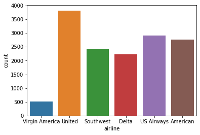

```python
sns.countplot(data = df, x='airline')
plt.show()
```

- Most tweets are directed towards United (26.1%) followed by US Airways(19.9%) and American Airlines (18.8%)

```python
df['airline_sentiment'].value_counts()/df['airline_sentiment'].count()*100
```

```
negative    62.691257
neutral     21.168033
positive    16.140710
Name: airline_sentiment, dtype: float64
```

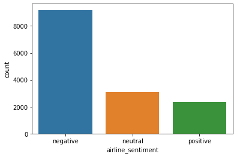

```python
sns.countplot(data = df, x='airline_sentiment', order = ['negative','neutral','positive'])
plt.show()
```

- Most tweets have a negative sentiment (62.7%) followed by neutral (21.2%) then positive (16.1%)

```python
united = df[df['airline']== 'United']
united['airline_sentiment'].value_counts()/united['airline_sentiment'].count()*100
```

```
negative    68.890633
neutral     18.236525
positive    12.872841
Name: airline_sentiment, dtype: float64
```

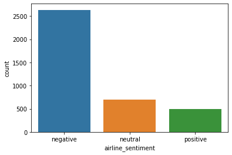

```python
sns.countplot(data = df[df['airline']== 'United'], x='airline_sentiment', order = ['negative','neutral','positive'])
plt.show()
```

- Most United tweets have a negative sentiment (68.9%), followed by neutral (18.2%) then positive (12.9%)

```python
USA = df[df['airline']== 'US Airways']
USA['airline_sentiment'].value_counts()/USA['airline_sentiment'].count()*100
```

```
negative    77.686234
neutral     13.079300
positive     9.234466
Name: airline_sentiment, dtype: float64
```

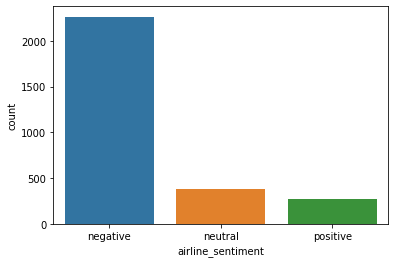

```python
sns.countplot(data = df[df['airline']== 'US Airways'], x='airline_sentiment', order = ['negative','neutral','positive'])
plt.show()
```

- Most US airways tweets have a negative sentiment (77.7%), followed by neutral (13.1%) then positive (9.2%)

```python
AA = df[df['airline']== 'American']
AA['airline_sentiment'].value_counts()/AA['airline_sentiment'].count()*100
```

```
negative    71.040232
neutral     16.781443
positive    12.178325
Name: airline_sentiment, dtype: float64
```

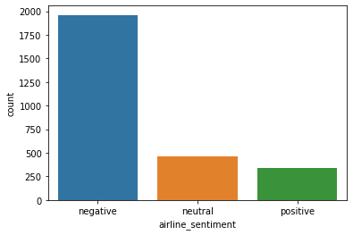

```python
sns.countplot(data = df[df['airline']== 'American'], x='airline_sentiment', order = ['negative','neutral','positive'])
plt.show()
```

- Most American Airlines tweets have a negative sentiment (71%), followed by neutral (16.8%) then positive (12.2%)

```python
SA = df[df['airline']== 'Southwest']
SA['airline_sentiment'].value_counts()/SA['airline_sentiment'].count()*100
```

```
negative    49.008264
neutral     27.438017
positive    23.553719
Name: airline_sentiment, dtype: float64
```

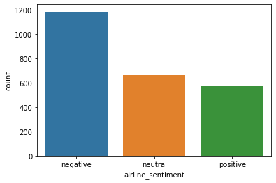

```python
sns.countplot(data = df[df['airline']== 'Southwest'], x='airline_sentiment', order = ['negative','neutral','positive'])
plt.show()
```

- Most Southwest Airline tweets have a negative sentiment (49%), followed by neutral (27.4%) then positive (23.6%)

```python
DA = df[df['airline']== 'Delta']
DA['airline_sentiment'].value_counts()/DA['airline_sentiment'].count()*100
```

```
negative    42.979298
neutral     32.538254
positive    24.482448
Name: airline_sentiment, dtype: float64
```

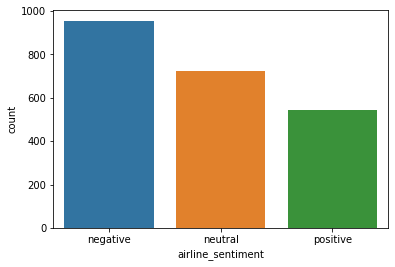

```python
sns.countplot(data = df[df['airline']== 'Delta'], x='airline_sentiment', order = ['negative','neutral','positive'])
plt.show()
```

- Most Delta Airline tweets have a negative sentiment (43%), followed by neutral (32.5%) then positive (24.5%)

```python
VAA = df[df['airline']== 'Virgin America']
VAA['airline_sentiment'].value_counts()/VAA['airline_sentiment'].count()*100
```

```
negative    35.912698
neutral     33.928571
positive    30.158730
Name: airline_sentiment, dtype: float64
```

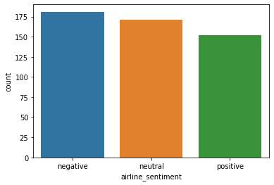

```python
sns.countplot(data = df[df['airline']== 'Virgin America'], x='airline_sentiment', order = ['negative','neutral','positive'])
plt.show()
```

- Most Virgin America tweets have a negative sentiment (35.9%), followed by neutral (33.9%) then positive (30.2%)

```python
df['negativereason'].value_counts()/df['negativereason'].count()*100
```

```
Can't Tell                     45.437158
Customer Service Issue         19.877049
Late Flight                    11.372951
Cancelled Flight                5.785519
Lost Luggage                    4.945355
Bad Flight                      3.961749
Flight Booking Problems         3.613388
Flight Attendant Complaints     3.285519
longlines                       1.215847
Damaged Luggage                 0.505464
Name: negativereason, dtype: float64
```

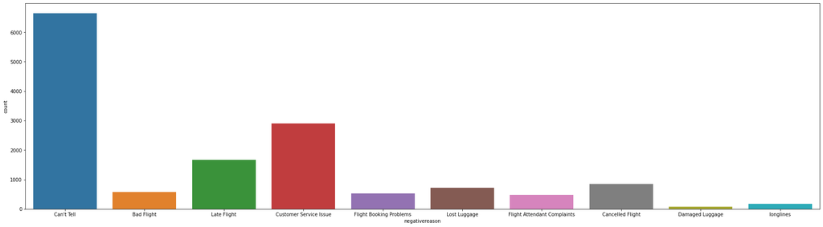

```python
fig1, ax1 = plt.subplots(figsize=(30, 8))
sns.countplot(data = df, x='negativereason')
plt.show()
```

- Most negative reasons are unknown/can't tell, this may because of all the null values so disregarding that, the next most common negative reason is Customer service issue (19.9%), followed by Late Flight(11.4%) and Cancelled Flight(5.8%)

### Data Preprocessing

#### Dropping columns

```python
df.head()
```

|  | airline_sentiment | negativereason | airline | text |
| --- | --- | --- | --- | --- |
| 0 | neutral | Can't Tell | Virgin America | @VirginAmerica What @dhepburn said. |
| 1 | positive | Can't Tell | Virgin America | @VirginAmerica plus you've added commercials t... |
| 2 | neutral | Can't Tell | Virgin America | @VirginAmerica I didn't today... Must mean I n... |
| 3 | negative | Bad Flight | Virgin America | @VirginAmerica it's really aggressive to blast... |
| 4 | negative | Can't Tell | Virgin America | @VirginAmerica and it's a really big bad thing... |

- We've used negative reason and airline for EDA but its unecesary for predicitons and modelling so we will drop them

```python
df.drop(['negativereason','airline'],axis=1,inplace=True)
df.head()                                                               # Checking to see if dropped
```

|  | airline_sentiment | text |
| --- | --- | --- |
| 0 | neutral | @VirginAmerica What @dhepburn said. |
| 1 | positive | @VirginAmerica plus you've added commercials t... |
| 2 | neutral | @VirginAmerica I didn't today... Must mean I n... |
| 3 | negative | @VirginAmerica it's really aggressive to blast... |
| 4 | negative | @VirginAmerica and it's a really big bad thing... |

#### HTML Tag Removal

```python
def strip_html(text):
    soup = BeautifulSoup(text, "html.parser")
    return soup.get_text()
```

```python
df['text'] = data['text'].apply(lambda x: strip_html(x))
```

Stripping HTML text through Beautifulsoup parser

#### Number Removal

```python
def remove_numbers(text):
  text = re.sub(r'\d+', '', text)
  return text
```

```python
df['text'] = df['text'].apply(lambda x: remove_numbers(x))
```

- Number removal via re.sub function

#### Tokenization

```python
df['text'] = df.apply(lambda x: nltk.word_tokenize(x['text']), axis=1) # Tokenization of data
```

- Tokenization via NLTK to prepare text for lowercasing, stopword removal, lemetization and word normalization.

#### Removal of Special Characters and Punctuations

```python
def remove_punctuation(words):
    """Remove punctuation from list of tokenized words"""
    new_words = []
    for word in words:
        new_word = re.sub(r'[^\w\s]', '', word)
        if new_word != '':
            new_words.append(new_word)
    return new_words
```

```python
def remove_non_ascii(words):
    """Remove non-ASCII characters from list of tokenized words"""
    new_words = []
    for word in words:
        new_word = unicodedata.normalize('NFKD', word).encode('ascii', 'ignore').decode('utf-8', 'ignore')
        new_words.append(new_word)
    return new_words
```

```python
df['text'] = df['text'].apply(lambda x: remove_punctuation(x))
df['text'] = df['text'].apply(lambda x: remove_non_ascii(x))
```

- Re.sub and Unicode normalization

#### Turn all words to lowercase

```python
def to_lowercase(words):
    """Convert all characters to lowercase from list of tokenized words"""
    new_words = []
    for word in words:
        new_word = word.lower()
        new_words.append(new_word)
    return new_words
```

```python
df['text'] = df['text'].apply(lambda x: to_lowercase(x))
```

- Turning words lowercase

#### Stopword Removal

```python
stopwords = stopwords.words('english')
```

```python
customlist = ['not', "couldn't", 'didn', "didn't", 'doesn', "doesn't", 'hadn', "hadn't", 'hasn',
        "hasn't", 'haven', "haven't", 'isn', "isn't", 'ma', 'mightn', "mightn't", 'mustn',
        "mustn't", 'needn', "needn't", 'shan', "shan't", 'shouldn', "shouldn't", 'wasn',
        "wasn't", 'weren', "weren't", 'won', "won't", 'wouldn', "wouldn't"]
stopwords = list(set(stopwords) - set(customlist))
```

```python
def remove_stopwords(words):
    """Remove stop words from list of tokenized words"""
    new_words = []
    for word in words:
        if word not in stopwords:
            new_words.append(word)
    return new_words
```

```python
df['text'] = df['text'].apply(lambda x: remove_stopwords(x))
```

- Custom list so that we don't lose important words for sentiment analysis then removal of other stopwords for ease of processing

#### Lemitization

```python
lemmatizer = WordNetLemmatizer()
def lemmatize_list(words):
    new_words = []
    for word in words:
      new_words.append(lemmatizer.lemmatize(word, pos='v'))
    return new_words
```

```python
df['text'] = df['text'].apply(lambda x: lemmatize_list(x))
```

- Lemetization for ease of processing

#### Joining words

```python
def join_words(words):
  return ' '.join(words)
```

```python
df['text'] = df['text'].apply(lambda x: join_words(x))
```

```python
df.head()
```

|  | airline_sentiment | text |
| --- | --- | --- |
| 0 | neutral | virginamerica dhepburn say |
| 1 | positive | virginamerica plus add commercials experience ... |
| 2 | neutral | virginamerica nt today must mean need take ano... |
| 3 | negative | virginamerica really aggressive blast obnoxiou... |
| 4 | negative | virginamerica really big bad thing |

- returning words into a "sentence"

### Wordcloud

```python
positive = df[df['airline_sentiment']== 'positive']
negative = df[df['airline_sentiment']== 'negative']
```

- Tweets are separated into positive and negative sentiments for analysis, neutral prediction isnt too important here because they don't mean much to the airlines as we want to improve negative sentiment or build on positive sentiment

```python
positive['text'] = positive.apply(lambda x: nltk.word_tokenize(x['text']), axis=1)
negative['text'] = negative.apply(lambda x: nltk.word_tokenize(x['text']), axis=1)
```

- Tokenization for wordcloud

```python
def show_wordcloud(data, title):
    text = ' '.join(data['text'].astype(str).tolist())                    # Converting text column into list
    stopwords = set(wordcloud.STOPWORDS)                                  # instantiate the stopwords from wordcloud

    fig_wordcloud = wordcloud.WordCloud(stopwords=stopwords,background_color='white',          # Setting the different parameter of stopwords
                    colormap='viridis', width=800, height=600).generate(text)

    plt.figure(figsize=(14,11), frameon=True)
    plt.imshow(fig_wordcloud)
    plt.axis('off')
    plt.title(title, fontsize=30)
    plt.show()
```

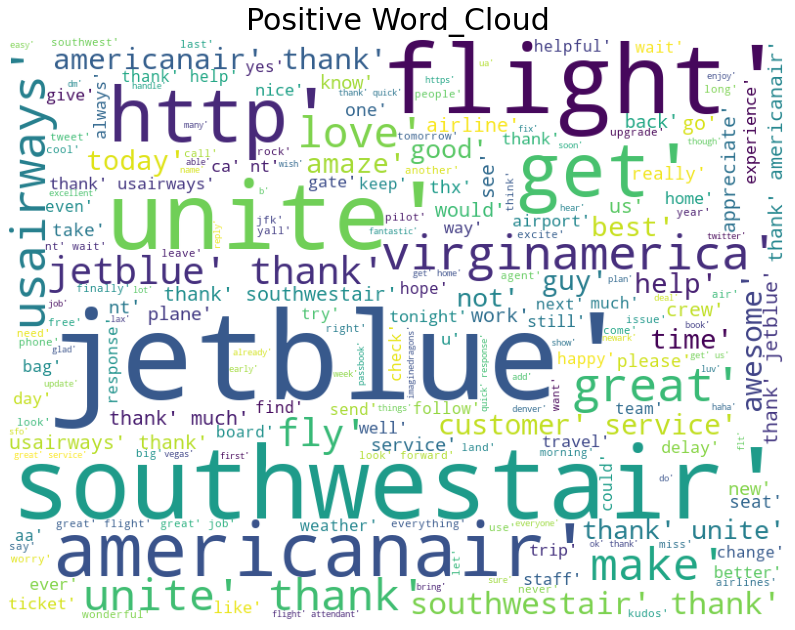

```python
show_wordcloud(positive,'Positive Word_Cloud')
```

- We are ignoring the airlines names as those don't constitute as positive words necessarily
- flight, get, jetblue, unite, fly, make, thank, great, love, customer, service were some of the important recurring words observed in the positive reviews

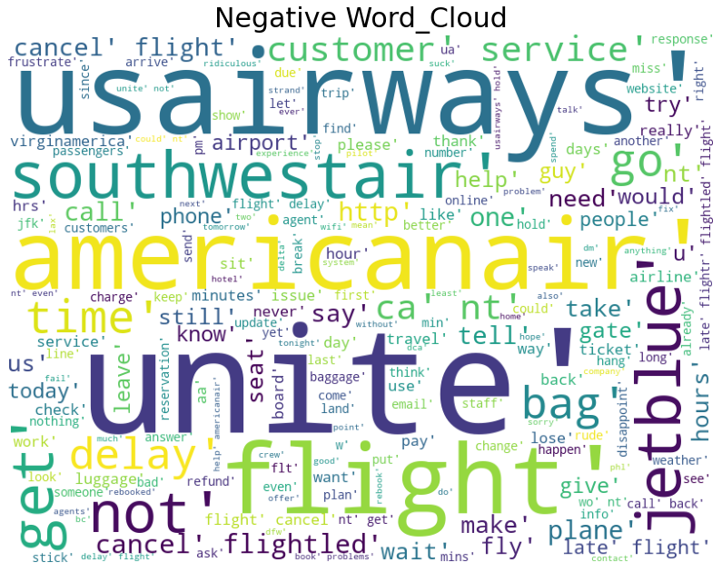

```python
show_wordcloud(negative,'Negative Word_Cloud')
```

- We are ignoring the airlines names as those don't constitute as negative words necessarily
- flight, not, time, unite, delay, go, jetblue, cancel, customer, service were some of the important recurring words observed in the negative reviews

### Vectorization

##### CountVectorizer

```python
Count_vec = CountVectorizer(max_features=500)                # Keep only 500 features as number of features will increase the processing time.
data_vec_features = Count_vec.fit_transform(df['text'])
data_vec_features = data_vec_features.toarray()                        # Convert the data features to array.
```

```python
data_vec_features.shape
```

```
(14640, 500)
```

##### TF-IDF Vectorizer

```python
tfidf_vect = TfidfVectorizer(max_features=500)
data_tfid_features = tfidf_vect.fit_transform(df['text'])
data_tfid_features = data_tfid_features.toarray()
```

```python
data_tfid_features.shape
```

```
(14640, 500)
```

### Modelling

#### CountVectorizer

```python
X = data_vec_features

y = df['airline_sentiment']
```

- Split into features and target predictor

```python
X_train, X_test, y_train, y_test = train_test_split(X, y, test_size=0.25, shuffle=False) #Splitting
```

```python
# Finding optimal number of base learners using k-fold CV ->
base_ln = np.arange(100,400,100).tolist()
base_ln
```

```
[100, 200, 300]
```

```python
# K-Fold Cross - validation .
cv_scores = []
for b in base_ln:
    clf = RandomForestClassifier(n_estimators = b)
    scores = cross_val_score(clf, X_train, y_train, cv = 5, scoring = 'accuracy')
    cv_scores.append(scores.mean())
```

- Model optimization of base learners

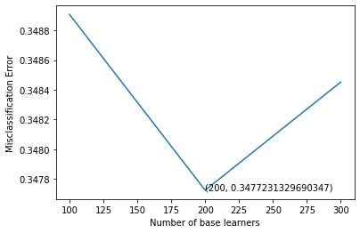

```python
# plotting the error as k increases
error = [1 - x for x in cv_scores]                                 #error corresponds to each nu of estimator
optimal_learners = base_ln[error.index(min(error))]                #Selection of optimal nu of n_estimator corresponds to minimum error.
plt.plot(base_ln, error)                                           #Plot between each nu of estimator and misclassification error
xy = (optimal_learners, min(error))
plt.annotate('(%s, %s)' % xy, xy = xy, textcoords='data')
plt.xlabel("Number of base learners")
plt.ylabel("Misclassification Error")
plt.show()
```

- Around 200 learners has the lowest miscallisification error

```python
# Training the best model and calculating accuracy on test data .
clf = RandomForestClassifier(n_estimators = optimal_learners)
clf.fit(X_train, y_train)
clf.score(X_test, y_test)
count_vectorizer_predicted = clf.predict(X_test)
print(classification_report(y_test ,count_vectorizer_predicted , target_names = ['negative', 'neutral' ,'positive']))
print("Accuracy of the model is : ",accuracy_score(y_test,count_vectorizer_predicted))
```

```
              precision    recall  f1-score   support

    negative       0.85      0.91      0.88      2627
     neutral       0.52      0.40      0.45       577
    positive       0.69      0.62      0.65       456

    accuracy                           0.79      3660
   macro avg       0.69      0.64      0.66      3660
weighted avg       0.78      0.79      0.78      3660

Accuracy of the model is :  0.7915300546448087
```

- Accuracy with 200 learners is above 75% target

```
[[2386  164   77]
 [ 297  229   51]
 [ 128   46  282]]
```

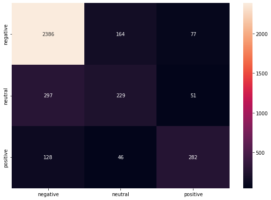

```python
conf_mat = confusion_matrix(y_test, count_vectorizer_predicted)

print(conf_mat)

df_cm = pd.DataFrame(conf_mat, index = [i for i in ['negative', 'neutral' ,'positive']],
                  columns = [i for i in ['negative', 'neutral' ,'positive']])
plt.figure(figsize = (10,7))
sns.heatmap(df_cm, annot=True, fmt='g')
```

```
thank,nt,not,delay,unite,usairways,jetblue,great,flight,http,southwestair,get,love,hold,hours,awesome,bag,cancel,wait,hour,amaze,virginamerica,please,make,fly,time,go,best,would,help,good,customer,airline,service,need,plane,us,call,know,dm,
```

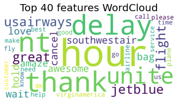

```python
all_features = Count_vec.get_feature_names()              #Instantiate the feature from the vectorizer
top_features=''                                            # Addition of top 40 feature into top_feature after training the model
feat=clf.feature_importances_
features=np.argsort(feat)[::-1]
for i in features[0:40]:
    top_features+=all_features[i]
    top_features+=','

print(top_features)

print(" ")
print(" ")

from wordcloud import WordCloud
wordcloud = WordCloud(background_color="white",colormap='viridis',width=2000,
                          height=1000).generate(top_features)

# Display the generated image:
plt.imshow(wordcloud, interpolation='bilinear')
plt.figure(1, figsize=(14, 11), frameon='equal')
plt.title('Top 40 features WordCloud', fontsize=20)
plt.axis("off")
plt.show()
```